# Optional Quizz

Federico Gonzalez

12/03/2018

## Optional Quizz

Your assignment is to study how income varies across different categories of college majors. You will be using data from a study of recent college graduates. Make sure to use good practices that you have learned so far in this course and previous courses in the specialization. In particular, it is good practice to specify an analysis plan early in the process to avoid the “p-hacking” behavior of trying many analyses to find one that has desired results. If you want to learn more about “p-hacking”, you can visit https://projects.fivethirtyeight.com/p-hacking/.

Your assignment is to study how income varies across college major categories. Specifically answer: “Is there an association between college major category and income?”

To get started, start a new R/RStudio session with a clean workspace. To do this in R, you can use the q() function to quit, then reopen R. The easiest way to do this in RStudio is to quit RStudio entirely and reopen it. After you have started a new session, run the following commands. This will load a data.frame called college for you to work with.

```r
install.packages("devtools")
devtools::install_github("jhudsl/collegeIncome")
```

```r
library(collegeIncome)
data(college)
```

Next download and install the matahari R package with the following commands:

```r
devtools::install_github("jhudsl/matahari")
```

```r
library(matahari)
```

This package allows a record of your analysis (your R command history) to be documented. You will be uploading a file containing this record to GitHub and submitting the link as part of this quiz.

Before you start the analysis for this assignment, enter the following command to begin the documentation of your analysis:

```r
dance_start(value = FALSE, contents = FALSE)
```

You can then proceed with the rest of your analysis in R as usual. When you have finished your analysis, use the following command to save the record of your analysis on your desktop:

```r
dance_save("~/Desktop/college_major_analysis.rds")
```

Please upload this college_major_analysis.rds file to a public GitHub repository. In question 4 of this quiz, you will share the link to this file.

A codebook for the dataset is given below:

- rank: Rank by median earnings
- major_code: Major code
- major: Major description
- major_category: Category of major
- total: Total number of people with major
- sample_size: Sample size of full-time, year-round individuals used for income/earnings estimates: p25th, median, p75th
- p25th: 25th percentile of earnings
- median: Median earnings of full-time, year-round workers
- p75th: 75th percentile of earnings
- perc_men: % men with major (out of total)
- perc_women: % women with major (out of total)
- perc_employed: % employed (out of total)
- perc_employed_fulltime: % employed 35 hours or more (out of employed)
- perc_employed_parttime: % employed less than 35 hours (out of employed)
- perc_employed_fulltime_yearround: % employed at least 50 weeks and at least 35 hours (out of employed and full-time)
- perc_unemployed: % unemployed (out of employed)
- perc_college_jobs: % with job requiring a college degree (out of employed)
- perc_non_college_jobs: % with job not requiring a college degree (out of employed)
- perc_low_wage_jobs: % in low-wage service jobs (out of total)

### Hypothesis

Question: Based on your analysis, would you conclude that there is a significant association between college major category and income?

#### Loading dependencies

```r
library(dplyr)
```

#### Exploratory Analysis

```r
dim(college)
```

```
## [1] 173  19
```

```r
head(college,3)
```

```
##   rank major_code                          major major_category total
## 1    1       2419          Petroleum Engineering    Engineering  2339
## 2    2       2416 Mining And Mineral Engineering    Engineering   756
## 3    3       2415      Metallurgical Engineering    Engineering   856
##   sample_size perc_women p25th median p75th   perc_men perc_employed
## 1          36  0.9109326 25000  40000 50000 0.08906743     0.9115044
## 2           7  0.5154064 26000  37000 40000 0.48459355     0.7980501
## 3           3  0.5942076 26700  45000 60000 0.40579235     0.7871943
##   perc_employed_fulltime perc_employed_parttime
## 1              0.9206524              0.1774785
## 2              0.7110092              0.3623853
## 3              0.8833498              0.3387257
##   perc_employed_fulltime_yearround perc_unemployed perc_college_jobs
## 1                        0.7704431      0.08849558         0.6702970
## 2                        0.7093101      0.20194986         0.3867764
## 3                        0.7738366      0.21280567         0.7289116
##   perc_non_college_jobs perc_low_wage_jobs
## 1             0.1821782         0.05544554
## 2             0.5158761         0.21560172
## 3             0.1759983         0.03014828
```

```r
str(college)
```

```
## 'data.frame':    173 obs. of  19 variables:
##  $ rank                            : int  1 2 3 4 5 6 7 8 9 10 ...
##  $ major_code                      : int  2419 2416 2415 2417 2405 2418 6202 5001 2414 2408 ...
##  $ major                           : chr  "Petroleum Engineering" "Mining And Mineral Engineering" "Metallurgical Engineering" "Naval Architecture And Marine Engineering" ...
##  $ major_category                  : chr  "Engineering" "Engineering" "Engineering" "Engineering" ...
##  $ total                           : int  2339 756 856 1258 32260 2573 3777 1792 91227 81527 ...
##  $ sample_size                     : int  36 7 3 16 289 17 51 10 1029 631 ...
##  $ perc_women                      : num  0.911 0.515 0.594 0.652 0.418 ...
##  $ p25th                           : num  25000 26000 26700 26000 31500 23000 32500 37900 29200 23000 ...
##  $ median                          : num  40000 37000 45000 35000 62000 44700 45000 57000 36000 32200 ...
##  $ p75th                           : num  50000 40000 60000 45000 109000 50000 58000 67000 46000 47100 ...
##  $ perc_men                        : num  0.0891 0.4846 0.4058 0.3479 0.5821 ...
##  $ perc_employed                   : num  0.912 0.798 0.787 0.847 0.852 ...
##  $ perc_employed_fulltime          : num  0.921 0.711 0.883 0.937 0.809 ...
##  $ perc_employed_parttime          : num  0.177 0.362 0.339 0.167 0.402 ...
##  $ perc_employed_fulltime_yearround: num  0.77 0.709 0.774 0.653 0.685 ...
##  $ perc_unemployed                 : num  0.0885 0.2019 0.2128 0.1534 0.1484 ...
##  $ perc_college_jobs               : num  0.67 0.387 0.729 0.246 0.587 ...
##  $ perc_non_college_jobs           : num  0.182 0.516 0.176 0.411 0.386 ...
##  $ perc_low_wage_jobs              : num  0.0554 0.2156 0.0301 0.0432 0.118 ...
```

```r
mean(college$perc_employed+college$perc_unemployed)
```

```
## [1] 1
```

```r
mean(college$perc_men + college$perc_women)
```

```
## [1] 1
```

```r
sum(is.na(college))
```

```
## [1] 4
```

```r
unique(college$major_category)
```

```
##  [1] "Engineering"
##  [2] "Business"
##  [3] "Physical Sciences"
##  [4] "Law & Public Policy"
##  [5] "Computers & Mathematics"
##  [6] "Agriculture & Natural Resources"
##  [7] "Industrial Arts & Consumer Services"
##  [8] "Arts"
##  [9] "Health"
## [10] "Social Science"
## [11] "Biology & Life Science"
## [12] "Education"
## [13] "Humanities & Liberal Arts"
## [14] "Psychology & Social Work"
## [15] "Communications & Journalism"
## [16] "Interdisciplinary"
```

##### Quick summary of major category dispertion

```r
with(college,aggregate(median,list(major_category), function(x) {c(Length= round(length(x),1) , Mean= round(mean(x),1), Var= round(var(x),1) )} ))
```

```
##                                Group.1    x.Length      x.Mean       x.Var
## 1      Agriculture & Natural Resources        10.0     43500.0 166500000.0
## 2                                 Arts         8.0     38050.0 151448571.4
## 3               Biology & Life Science        14.0     43864.3 183180934.1
## 4                             Business        13.0     49153.8 460307692.3
## 5          Communications & Journalism         4.0     42000.0  86000000.0
## 6              Computers & Mathematics        11.0     34718.2  22693636.4
## 7                            Education        16.0     37937.5  26846500.0
## 8                          Engineering        29.0     40393.1  91774950.7
## 9                               Health        12.0     40316.7  82521515.2
## 10           Humanities & Liberal Arts        15.0     35166.7  72860952.4
## 11 Industrial Arts & Consumer Services         7.0     40428.6 112472381.0
## 12                   Interdisciplinary         1.0     27500.0          NA
## 13                 Law & Public Policy         5.0     37800.0  87700000.0
## 14                   Physical Sciences        10.0     40400.0 187822222.2
## 15            Psychology & Social Work         9.0     39888.9 111361111.1
## 16                      Social Science         9.0     39066.7  98477500.0
```

As major “Interdiciplinary”" has only one data row and no model can be constructed fromo it, it will be removed.

```r
college <- college %>% filter(major_category != "Interdisciplinary")
```

Additionally, Range of the percentages values will be verified to be between 0 and 1.

```r
apply(college,2,range)
```

```
##      rank  major_code major        major_category
## [1,] "  1" "1100"     "Accounting" "Agriculture & Natural Resources"
## [2,] "173" "6403"     "Zoology"    "Social Science"
##      total    sample_size perc_women   p25th   median   p75th
## [1,] "   124" "   2"      "0.00000000" "18500" " 22000" " 22000"
## [2,] "393735" "4212"      "0.96895368" "95000" "110000" "125000"
##      perc_men     perc_employed perc_employed_fulltime
## [1,] "0.03104632" "0.0000000"   "      Inf"
## [2,] "1.00000000" "0.9561650"   "1.4102902"
##      perc_employed_parttime perc_employed_fulltime_yearround
## [1,] NA                     "0.5856515"
## [2,] NA                     "1.0000000"
##      perc_unemployed perc_college_jobs perc_non_college_jobs
## [1,] "0.04383502"    NA                NA
## [2,] "1.00000000"    NA                NA
##      perc_low_wage_jobs
## [1,] NA
## [2,] NA
```

```r
college[college$perc_employed_fulltime>1,]
```

```
##     rank major_code                                           major
## 17    17       2412        Industrial And Manufacturing Engineering
## 46    46       2105                            Information Sciences
## 58    58       6200                                General Business
## 63    63       6299 Miscellaneous Business & Medical Administration
## 133  134       2309                     Secondary Teacher Education
## 147  148       2306          Physical And Health Education Teaching
## 167  168       3302                        Composition And Rhetoric
##                major_category  total sample_size perc_women p25th median
## 17                Engineering  18968         183  0.5910010 25000  35000
## 46    Computers & Mathematics  11913         158  0.2926070 24000  35000
## 58                   Business 234590        2380  0.5585480 19200  29000
## 63                   Business  17947         244  0.2491902 95000 110000
## 133                 Education  17125         156  0.1250347 18500  35000
## 147                 Education  28213         259  0.6329868 30400  40000
```

[output cut: 33 more lines]

```r
college <- college %>% filter(perc_employed_fulltime <= 1 | perc_employed_fulltime != "Inf")
```

#### Exploratory Data Plots

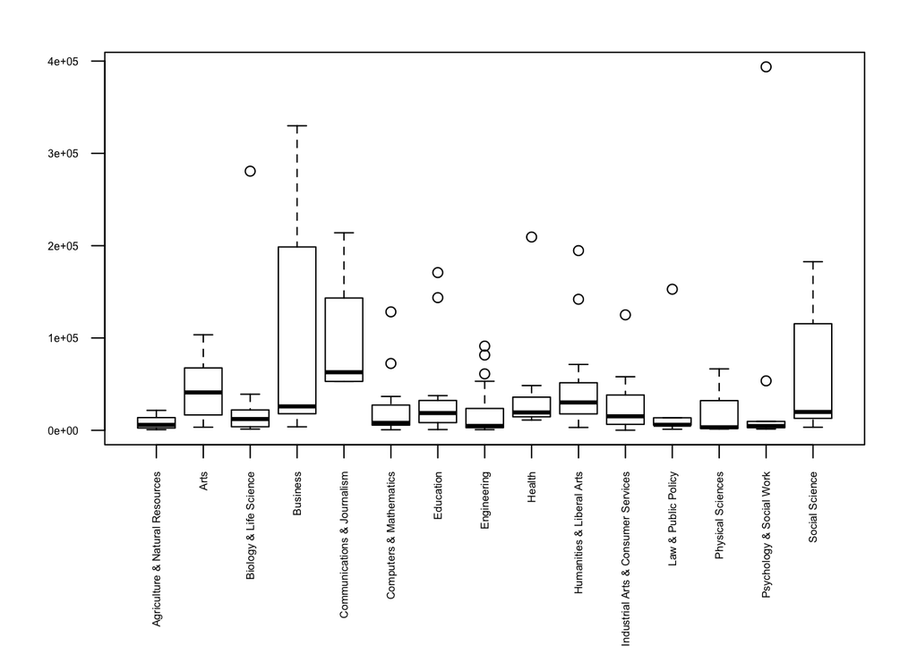

```r
college$major_category <- as.factor(college$major_category)
# Total number of people with major
par(mar=c(8,4,2,2), cex.axis=0.5 )
plot(as.factor(college$major_category),college$total, las=2)
```

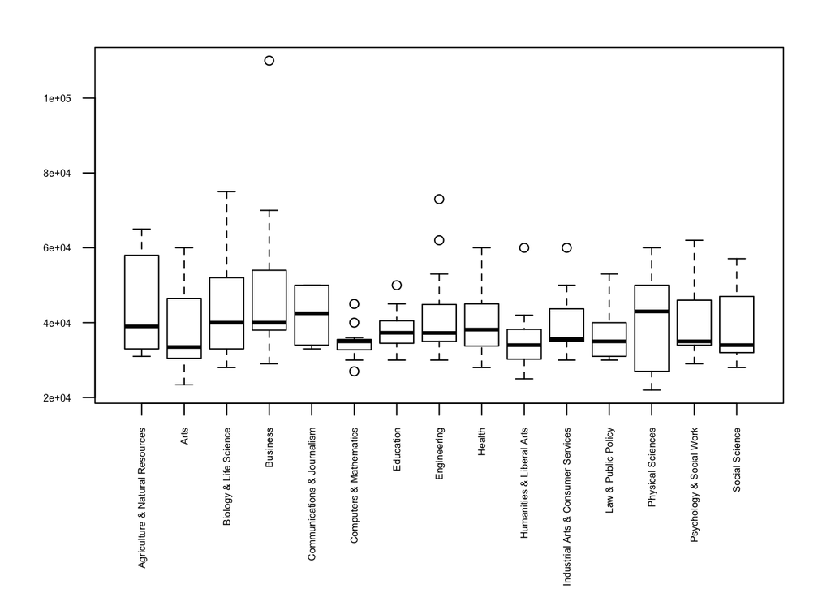

```r
# See the median in earnings for each category
plot(as.factor(college$major_category), college$median, las=2)
```

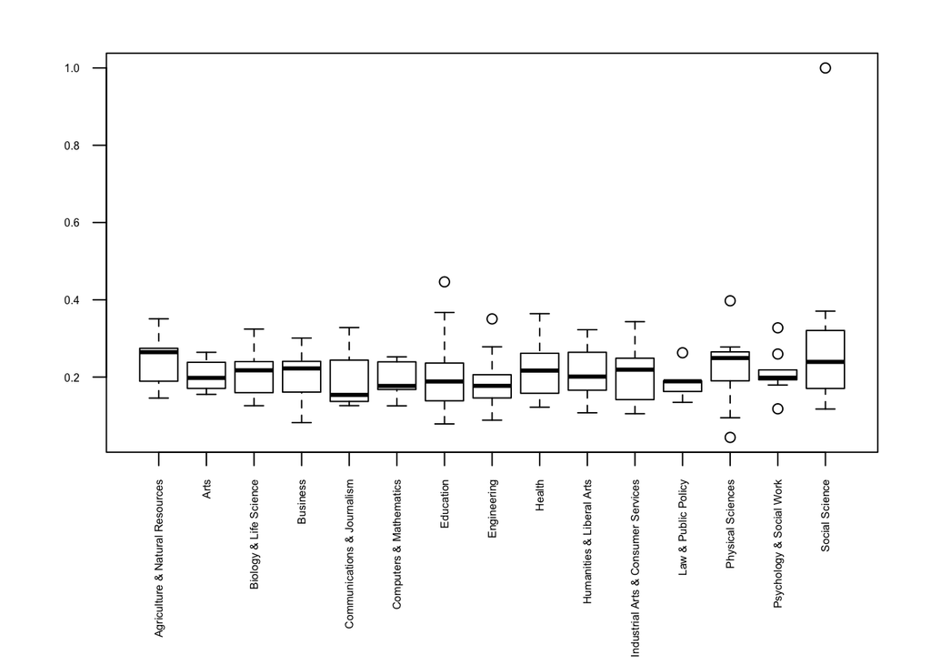

```r
# See the % of people unemployed per category
par(mar=c(8,4,2,2), cex.axis=0.5 )
plot(as.factor(college$major_category),college$perc_unemployed, las=2)
```

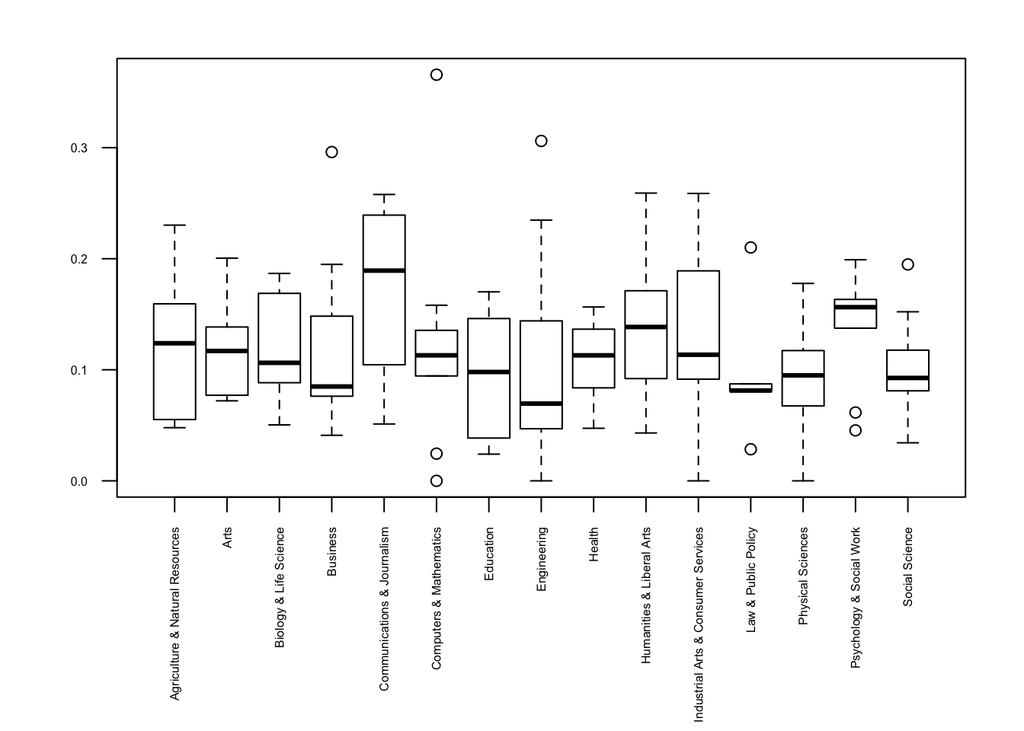

```r
# Percentage of people with low wage jobs out of total
par(mar=c(8,4,2,2), cex.axis=0.5 )
plot(as.factor(college$major_category),college$perc_low_wage_jobs, las=2)
```

#### Recalculating percentages from dataset

The percentages columns will be transformed to No. of people in order to make the analysis.

```r
college$No.Women <- college$total*college$perc_women
college$No.Men <- college$total*college$perc_men
college$No.Employed <- college$total*college$perc_employed
college$No.Unemployed <- college$total*college$perc_unemployed
college$No.Employed_Fulltime <- college$No.Employed*college$perc_employed_fulltime
college$No.Employed_Parttime <- college$No.Employed*college$perc_employed_parttime
college$No.Employed_fulltime_yearround <- college$No.Employed_Fulltime*college$perc_employed_fulltime_yearround
college$No.College_jobs <- college$No.Employed*college$perc_college_jobs
college$No.Non_college_jobs <- college$No.Employed*college$perc_non_college_jobs
college$No.Low_wage_jobs <- college$total*college$perc_low_wage_jobs

college2 <- college[,c(4,5,9,20:29)]
college2[rowSums(is.na(college2)) > 0,]
```

```
##             major_category total median No.Women   No.Men No.Employed
## 42 Computers & Mathematics 36698  32500 25950.49 10747.51    30482.93
##    No.Unemployed No.Employed_Fulltime No.Employed_Parttime
## 42      6215.074             26484.09             7309.347
##    No.Employed_fulltime_yearround No.College_jobs No.Non_college_jobs
## 42                       20716.94             NaN                 NaN
##    No.Low_wage_jobs
## 42              NaN
```

```r
college2 <- college2[complete.cases(college2),]
```

##### Taking a look to a density plot to see the disopersion of data

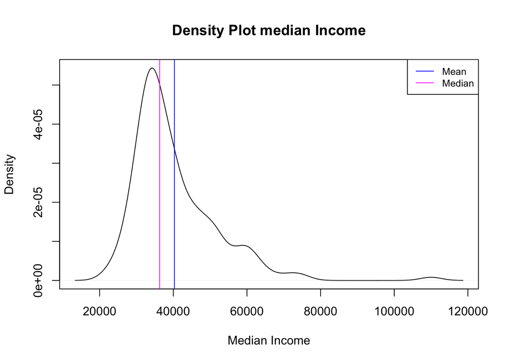

```r
plot(density(college2$median), xlab = "Median Income", ylab = "Density", main = "Density Plot median Income")
abline(v=mean(college2$median), col="blue")
abline(v=median(college2$median), col="magenta")
legend("topright", legend = c("Mean", "Median"), col = c("Blue","Magenta"), lty=1, cex=0.8)
```

The distribution doesn’t follow a normal distribution

#### Adjustment

```r
fit <- lm(median ~ major_category - 1 , data=college2)
summary(fit)
```

```
##
## Call:
## lm(formula = median ~ major_category - 1, data = college2)
##
## Residuals:
##    Min     1Q Median     3Q    Max
## -20154  -6813  -2937   4843  60846
##
## Coefficients:
##                                                   Estimate Std. Error
## major_categoryAgriculture & Natural Resources        43500       3611
## major_categoryArts                                   38050       4037
## major_categoryBiology & Life Science                 43864       3052
## major_categoryBusiness                               49154       3167
## major_categoryCommunications & Journalism            42000       5709
## major_categoryComputers & Mathematics                34940       3611
## major_categoryEducation                              37938       2854
## major_categoryEngineering                            40586       2158
## major_categoryHealth                                 40317       3296
## major_categoryHumanities & Liberal Arts              35167       2948
## major_categoryIndustrial Arts & Consumer Services    40429       4316
## major_categoryLaw & Public Policy                    37800       5106
## major_categoryPhysical Sciences                      40400       3611
## major_categoryPsychology & Social Work               39889       3806
## major_categorySocial Science                         39067       3806
##                                                   t value Pr(>|t|)
## major_categoryAgriculture & Natural Resources      12.047  < 2e-16 ***
## major_categoryArts                                  9.425  < 2e-16 ***
## major_categoryBiology & Life Science               14.374  < 2e-16 ***
## major_categoryBusiness                             15.521  < 2e-16 ***
## major_categoryCommunications & Journalism           7.357 1.03e-11 ***
## major_categoryComputers & Mathematics               9.677  < 2e-16 ***
## major_categoryEducation                            13.290  < 2e-16 ***
## major_categoryEngineering                          18.809  < 2e-16 ***
## major_categoryHealth                               12.231  < 2e-16 ***
## major_categoryHumanities & Liberal Arts            11.928  < 2e-16 ***
## major_categoryIndustrial Arts & Consumer Services   9.368  < 2e-16 ***
## major_categoryLaw & Public Policy                   7.403 7.97e-12 ***
## major_categoryPhysical Sciences                    11.189  < 2e-16 ***
## major_categoryPsychology & Social Work             10.480  < 2e-16 ***
## major_categorySocial Science                       10.264  < 2e-16 ***
## ---
## Signif. codes:  0 '***' 0.001 '**' 0.01 '*' 0.05 '.' 0.1 ' ' 1
##
## Residual standard error: 11420 on 155 degrees of freedom
## Multiple R-squared:  0.9323, Adjusted R-squared:  0.9257
## F-statistic: 142.3 on 15 and 155 DF,  p-value: < 2.2e-16
```

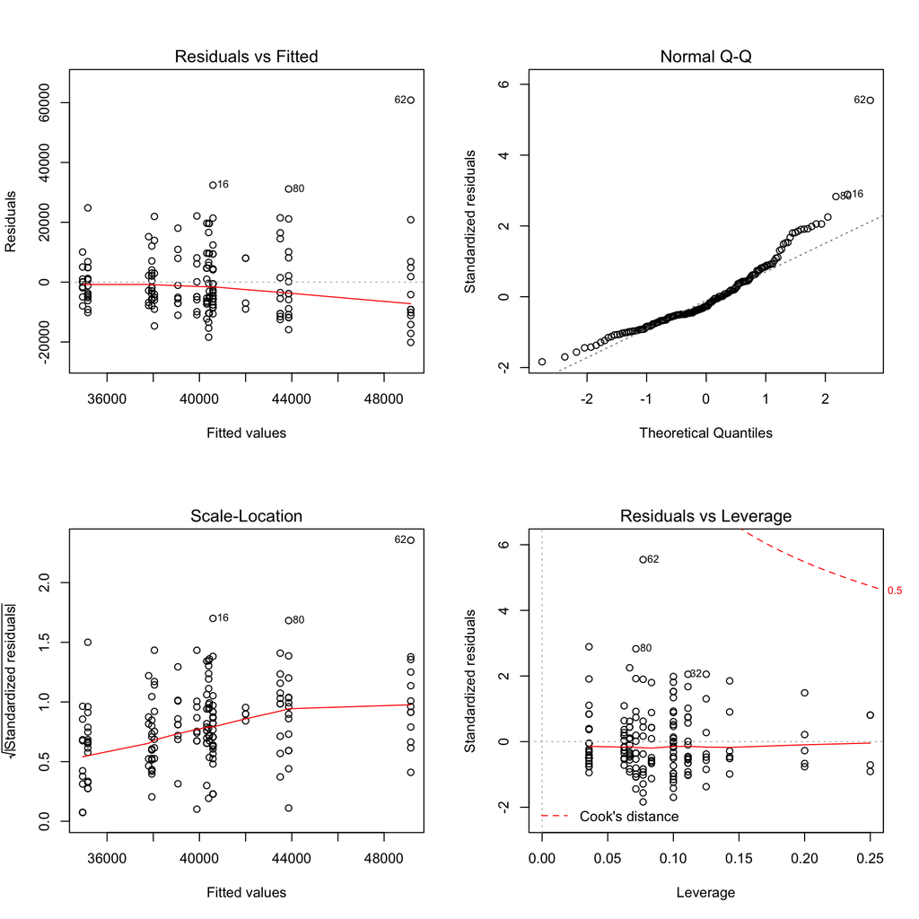

```r
par(mfrow = c(2, 2))
plot(fit)
```

##### Influence measures

```r
InfluenceM <- influence.measures(fit)
summary(InfluenceM)
```

```
## Potentially influential observations of
##   lm(formula = median ~ major_category - 1, data = college2) :
##
##     dfb.m&NR dfb.mj_A dfb.m&LS dfb.mj_B dfb.m_&J dfb.m_&M dfb.mjr_ctgryEd
## 16   0.00     0.00     0.00     0.00     0.00     0.00     0.00
## 19   0.00     0.00     0.00     0.00     0.00     0.00     0.00
## 62   0.00     0.00     0.00     1.78_*   0.00     0.00     0.00
## 80   0.00     0.00     0.80     0.00     0.00     0.00     0.00
## 87   0.00     0.00     0.00     0.00     0.00     0.00     0.00
## 89   0.00     0.00     0.00     0.00     0.00     0.00     0.00
## 93   0.00     0.00     0.00     0.00     0.47     0.00     0.00
## 94   0.00     0.00     0.00     0.00     0.00     0.00     0.00
## 96   0.00     0.00     0.00     0.00     0.47     0.00     0.00
## 98   0.00     0.00     0.00     0.00    -0.53     0.00     0.00
## 124  0.00     0.00     0.00     0.00    -0.41     0.00     0.00
```

[output cut: 24 more lines]

Form this summary, there are 11 rows that have high influence on the model that should be reviewed/removed.

##### Adjusting a new model removing outliers

```r
influencial.rows <- which(apply(InfluenceM$is.inf,1,any))

college2[influencial.rows,]
```

```
##                  major_category  total median    No.Women      No.Men
## 16                  Engineering   8925  73000   1067.0632   7857.9368
## 19          Law & Public Policy   1148  40000    980.9927    167.0073
## 62                     Business  17947 110000   4472.2172  13474.7828
## 80       Biology & Life Science  15232  75000   9588.6135   5643.3865
## 87          Law & Public Policy  13528  31000   9765.4021   3762.5979
## 89          Law & Public Policy   5629  30000   5222.6270    406.3730
## 93  Communications & Journalism 213996  50000 113917.3013 100078.6987
## 94          Law & Public Policy 152824  35000  34033.1410 118790.8590
## 96  Communications & Journalism  72619  50000  23366.5912  49252.4088
## 98  Communications & Journalism  53162  33000   9781.0206  43380.9794
## 124 Communications & Journalism  52824  35000   9197.8472  43626.1528
##     No.Employed No.Unemployed No.Employed_Fulltime No.Employed_Parttime
## 16    7287.0136     1637.9864            5382.8790            2633.3163
## 19     961.1721      186.8279             896.9829             158.8714
```

[output cut: 33 more lines]

```r
college3 <- college2[-influencial.rows,]
fit2 <- lm(median ~ major_category - 1 , data=college3)
summary(fit2)
```

```
##
## Call:
## lm(formula = median ~ major_category - 1, data = college3)
##
## Residuals:
##    Min     1Q Median     3Q    Max
## -18400  -6067  -1938   4997  25917
##
## Coefficients:
##                                                   Estimate Std. Error
## major_categoryAgriculture & Natural Resources        43500       3046
## major_categoryArts                                   38050       3406
## major_categoryBiology & Life Science                 41469       2672
## major_categoryBusiness                               44083       2781
## major_categoryComputers & Mathematics                34940       3046
## major_categoryEducation                              37938       2408
## major_categoryEngineering                            39385       1854
## major_categoryHealth                                 40317       2781
## major_categoryHumanities & Liberal Arts              35167       2487
## major_categoryIndustrial Arts & Consumer Services    40429       3641
## major_categoryLaw & Public Policy                    53000       9633
## major_categoryPhysical Sciences                      40400       3046
## major_categoryPsychology & Social Work               39889       3211
## major_categorySocial Science                         39067       3211
##                                                   t value Pr(>|t|)
## major_categoryAgriculture & Natural Resources      14.280  < 2e-16 ***
## major_categoryArts                                 11.172  < 2e-16 ***
## major_categoryBiology & Life Science               15.522  < 2e-16 ***
## major_categoryBusiness                             15.853  < 2e-16 ***
## major_categoryComputers & Mathematics              11.470  < 2e-16 ***
## major_categoryEducation                            15.753  < 2e-16 ***
## major_categoryEngineering                          21.245  < 2e-16 ***
## major_categoryHealth                               14.498  < 2e-16 ***
## major_categoryHumanities & Liberal Arts            14.139  < 2e-16 ***
## major_categoryIndustrial Arts & Consumer Services  11.104  < 2e-16 ***
## major_categoryLaw & Public Policy                   5.502 1.65e-07 ***
## major_categoryPhysical Sciences                    13.263  < 2e-16 ***
## major_categoryPsychology & Social Work             12.423  < 2e-16 ***
## major_categorySocial Science                       12.167  < 2e-16 ***
## ---
## Signif. codes:  0 '***' 0.001 '**' 0.01 '*' 0.05 '.' 0.1 ' ' 1
##
## Residual standard error: 9633 on 145 degrees of freedom
## Multiple R-squared:  0.9489, Adjusted R-squared:  0.944
## F-statistic: 192.4 on 14 and 145 DF,  p-value: < 2.2e-16
```

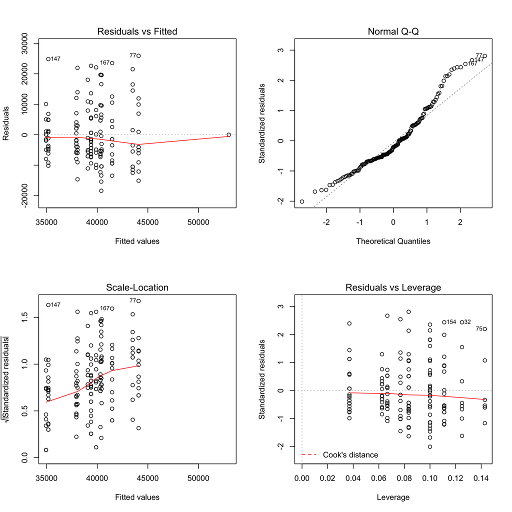

```r
par(mfrow = c(2, 2))
plot(fit2)
```

A different approach would be needed.

##### Conclusion

A different approach would be clustering Income data to compare vs Major Catgories for any given value of Income. This assumption is based on the pattern shown of the residuals dispertion plots that could make Income data comparable, in at least five ranges on Income.

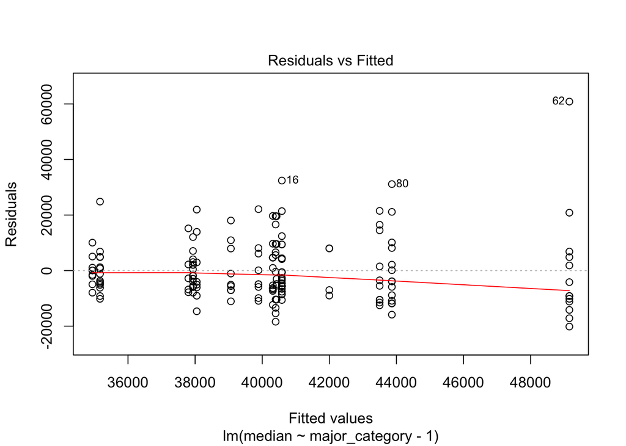

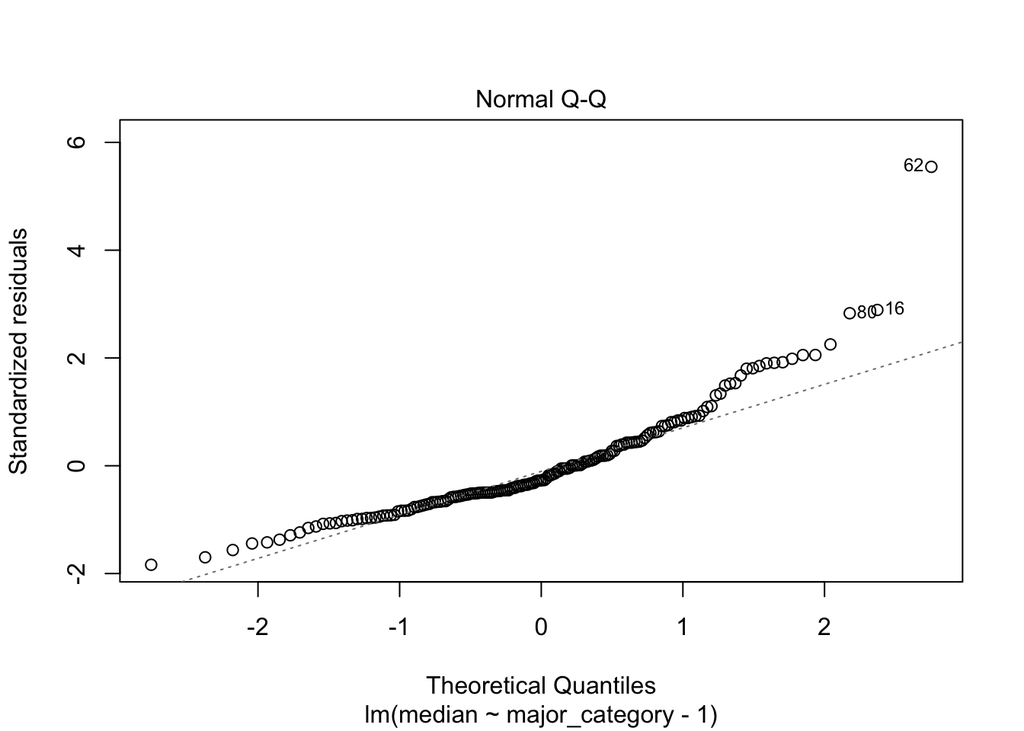

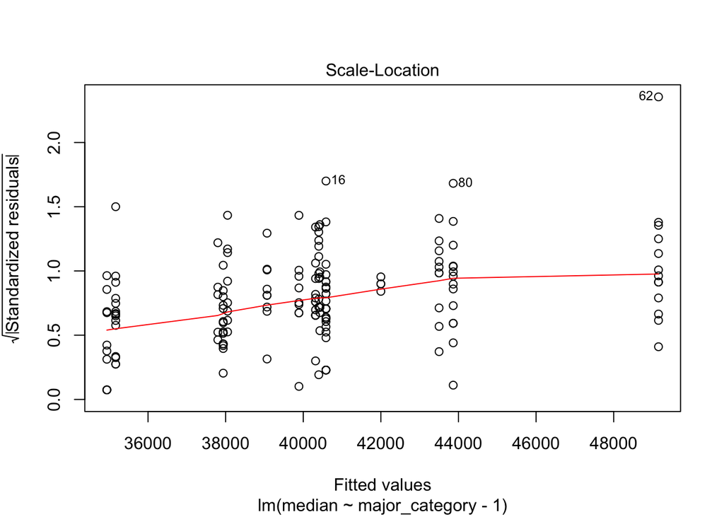

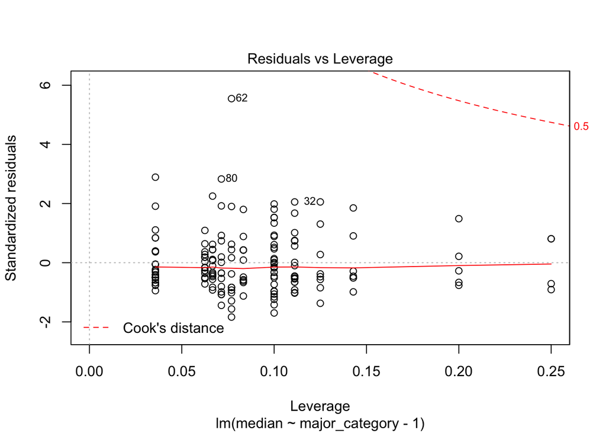

```r
plot(fit)[1]
```